# Juvenile Snowshoe Hare Weight and Size Comparison from Bonanza Creek Experimental Forest

By: Jenna Wisniewski

11/17/2020

#### **Introduction**

Snowshoe hares are a keystone prey species in their Alaskan habitat and their numbers affect important predators within the area. Their population shows large population fluxes around every ten years. Their population can also be found in varying numbers across different types of vegetation. At the Bonanza Creek Experimental Forest, capture-recapture studies were implemented to record population statistics and individual measurements of individuals. This report provides an exploratory overview of differences in juvenile snowshoe hare weights across sex and at three different testing locations containing varying vegetation and forest types at the Bonanza Creek Experimental Forest in Fairbanks, Alaska (mature stands of forest, a black spruce stand, and a riparian zone) during the years of 1999 to 2012. The relationship between juvenile hares hindfoot size and weight is also examined.

#### **Data and Analyses**

Hare counts and structural size measurements were collected and made available by Dr. Knut Kiellamd and colleagues at the Bonanza Creek Experimental Forest in Fairbanks, Alaska. The data contain observations for 3197 hare observations collected from the years 1999 to 2012, excluding the years of 2002 and 2009. The number of juvenile snowshoe hares was calculated for each year. Following exploratory data visualization, weights between male and female hares are compared by two-sample t-tests using a significance level ($\alpha$) of 0.05. The relationship between hindfoot length was also explored. Differences between variables are described by Cohen’s *d* effect size. The relationship is also explored by simple linear regression. All analyses are in R version 4.0.2 using RStudio version 1.3.1056.

#### **Exploratory Findings**

##### **A. Annual Juvenile Hare Trap Counts**

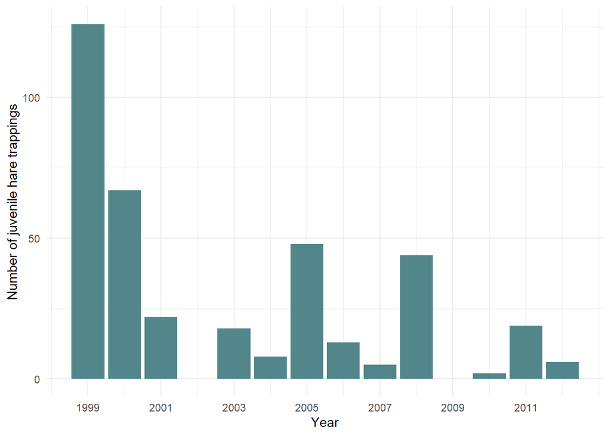

**Figure 1.** Total number of trapped juvenile snowshoe hares at Bonanza Creek from years 1999 to 2012, excluding years 2002 and 2009. Data: Kielland et. al.(2017)

The graph shows a higher amount of trapping in earlier years. The first year, 1999, had the maximum count if 126. The minimum count was in 2010 with 2 trappings. The mean number of counts for all years was 31.5. There is a pattern of low counts for two years and then a sharp increase of counts on the third year. In order to standardize the count of this population in future analyses, the same number of traps should be set for the same number of days each year. In order to standardize this in future analysis with the data that has already been collected, you could do something like divide by the trap count or by time spent trapping.

##### **B. Visualize Juvenile Hare Weights**

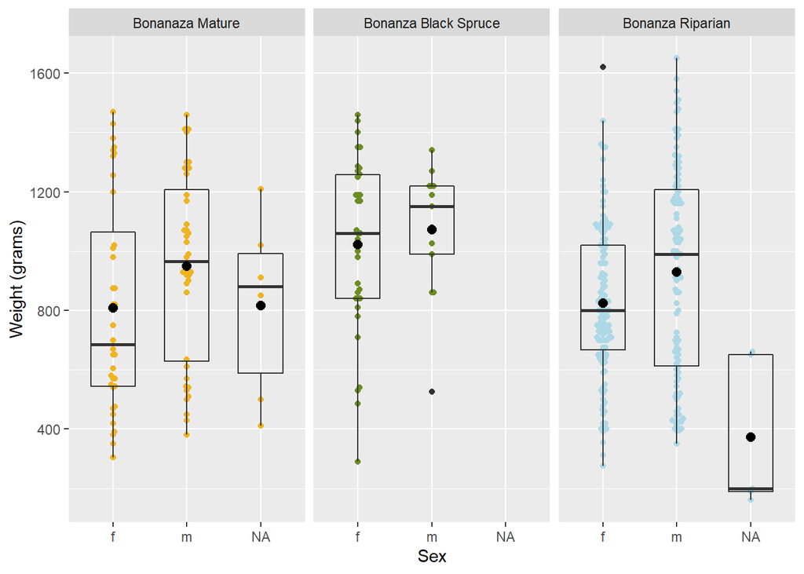

Distribution of weight for all three sites was relatively normal and symmetric, however it looks like more data and trapping is needed, especially in the Bonanza Mature and the Bonanza Black Spruce sites to further determine this. Across all sites, the male snowshoe hare’s weight has both a higher median and mean than the female’s. The juvenile hares at the Bonanza Black Spruce site have a higher mean and median than the other sites, the Bonanza Mature and Bonanza Riparian sites have very close means when comparing males and females.

##### **C. Juvenile Weight Comparison**

On average, juvenile male snowshoe hares are heavier than juvenile female snowshoe hares. (945.86 $\pm$ 333.22 and 855.39 $\pm$ 292.25 gm, respectively; mean $\pm$ 1 standard deviation). While the absolute difference in means is 90.47 gm (a 10.05% difference), the difference in means is significant (Welch’s two-sample t-test: t(325.02) = -2.71, p < 0.01), and the effect size is small (Cohen’s *d* = -0.29).

**Table 1.** Descriptive statistics (mean, standard deviation, and sample size) for the weight(grams) across sex in juvenile snowshoe hares Data: Kielland et. al.(2017).

| Sex | Mean Weight (gm) | Standard Deviation (gm) | Sample size |
| --- | --- | --- | --- |
| f | 855.3909 | 292.2526 | 200 |
| m | 945.8589 | 333.2151 | 163 |
| NA | 614.5455 | 357.5853 | 15 |

##### **D. Relationship between Juvenile Weight & Hind Foot Length**

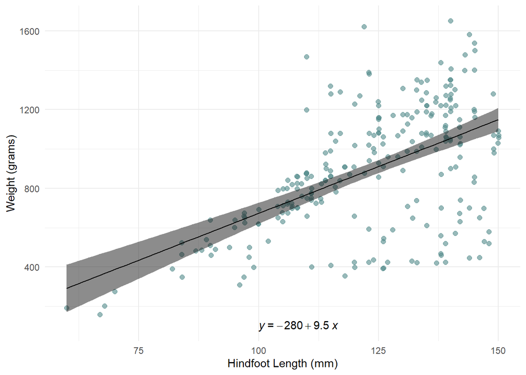

**Figure 3.** Relationship between weight (gm) and hind foot length (g) for juvenile hares. Points indicate individual hare weights.Linear model summary: $\beta$<sub>1</sub> = 9.52 g mm<sup>-1</sup>, p < 0.001, R<sup>2</sup> = 0.3, Pearson’s *r* = 0.55). Data: Kielland et. al.(2017).

#### **Summary**

Exploratory data analysis reveals these initial findings:

- Snowshoe hare counts were the highest when the trapping first started in 1999. There is a general pattern of counts increasing every three years and then dropping drastically the following year and staying low the next year as well.
- Data visualization showed the mean weight of juvenile males was higher than the mean weight of juvenile females across the three test sites.
- Data visualization showed the mean weight of juvenile hares was highest in the area containing Black Spruce stands and very similar within the Mature and Riparian stands.
- A t.test confirmed that the mean male juvenile hare weight is higher than mean female juvenile hare weight across trapped subjects.
- Hind foot length appears moderately linearly related with weight in juvenile hares, the relationship (by simple linear regression) is moderately significant, with 30% of the variation in weight accounted for by hindfoot length, with a slopes(expected average increase in weight with a 1 mm increase in hindfoot length) of 9.52 g mm<sup>-1</sup>.

Next Steps

- You could explore the relationship between the number of hare predators in the area and predators.
- Explore other relationships with hare observations such as pelt variations within different landscapes

#### **Citation**

Kielland, K., F.S. Chapin, R.W. Ruess, and Bonanza Creek LTER. 2017. Snowshoe hare physical data in Bonanza Creek Experimental Forest: 1999-Present ver 22. Environmental Data Initiative.